# Session 4: Biogeochemistry Hands-On Tutorial

Kaizad Patel

2023-11-08

**MONet Community Science Meeting 2023**

This tutorial contains code and scripts for preliminary processing and data visualization of soil biogeochemistry data. These graphs were created for use in Session 4 (Biogeochemistry Hands-On Tutorial) on Wednesday, November 8.

> **USING THIS TUTORIAL**  
> Download the [bgc_data file](https://github.com/EMSL-MONet/CommSciMtg_Nov23/blob/main/Biogeochem/data/bgc_data.csv). Create a new R Script file and save it in the **same** folder as the data file. Make sure both these files are saved in the same folder, to minimize errors with file paths.

> This file is a Markdown report, wich includes text as well as code chunks. You can copy the R code directly from these chunks and paste it into your R Script file.

## Setup

### Load packages

You will need the `{tidyverse}` set of packages to run this tutorial. The `tidyverse` includes packages like `{dplyr}` and `{tidyr}` for data wrangling, and `{ggplot2}` for data visualization.

```r
library(tidyverse) # for general data wrangling and visualization
theme_set(theme_bw(base_size = 12)) # set default ggplot theme
```

You may also want to download additional packages to jazz up your figures, such as the `{soilpalettes}` package, which includes soil-themed color palettes.

```r
# Install `soilpalettes` using:
# install.packages("devtools"); devtools::install_github("kaizadp/soilpalettes")

library(soilpalettes) # for color palettes
```

### Import files

We need only one file for this tutorial. This includes biogeochemical variables, and also has site metadata such as latitude-longitude and biome type.

You will need to change the file path before using this tutorial. The current file path reflects the directory structure in the GitHub repository.  
If you downloaded the tutorial and the data file into the same folder, change the code chunk below to `bgc_data = read_csv("bgc_data.csv")`

```r
bgc_data = read_csv("Biogeochem/data/bgc_data.csv")
```

One additional processing step before we start the tutorial – The `Location` column refers to the depth of the soil sample, “TOP” or “BTM”.  
By default, R sorts its data alphabetically. Change the order here, before proceeding.

```r
bgc_data =
  bgc_data %>%
  mutate(Location = factor(Location, levels = c("TOP", "BTM")))
```

Now, we begin with the plots and analyses.

Below are some examples with select variables. You can modify this code to try this with other variables of your choice.

## JITTER AND SCATTER PLOTS

Scatter plots and jitter plots help with basic exploratory analysis.

In jitter plots, the `geom_jitter` function adds a little bit of random noise to each data point, allowing some separation. This prevents overlapped points.

### JITTER PLOT: total carbon (TC) by depth

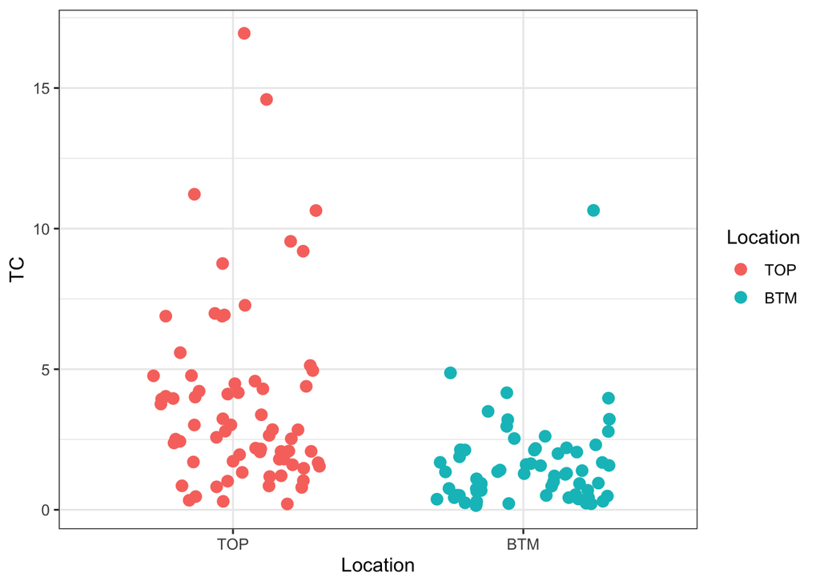

```r
bgc_data %>%
  ggplot(aes(x = Location, y = TC, color = Location))+
  geom_jitter(size = 3, width = 0.3)
```

### JITTER + BOX PLOT: total carbon (TC) by depth

Add another layer (boxplot) to the plot above.  
This shows us summary stats (median and quartiles) in addition to the spread of the data.

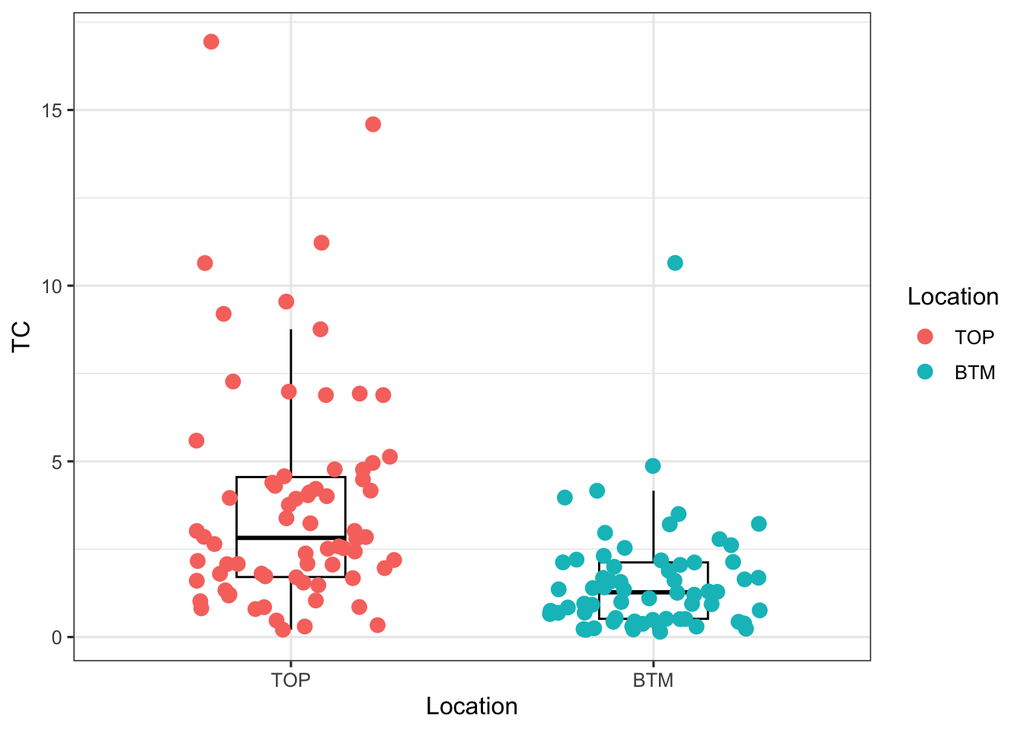

```r
bgc_data %>%
  ggplot(aes(x = Location, y = TC, color = Location))+
  geom_boxplot(position = position_dodge(width = 0.5),
               width = 0.3,
               outlier.colour = NA,
               color = "black")+
  geom_jitter(size = 3, width = 0.3)
```

### SCATTER PLOT: total carbon (TC) by biome

The next example is one of total carbon (continuous variable) plotted against biome (character variable)

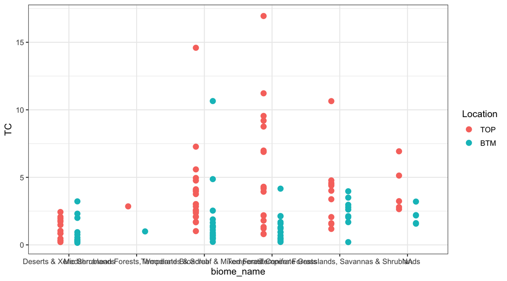

```r
bgc_data %>%
  ggplot(aes(x = biome_name, y = TC, color = Location))+
  geom_point(size = 3,
             position = position_dodge(width = 0.5))
```

Because of the long biome names, the x-axis is difficult to read.  
Try the `scale_x_discrete` command below to format the x-axis.

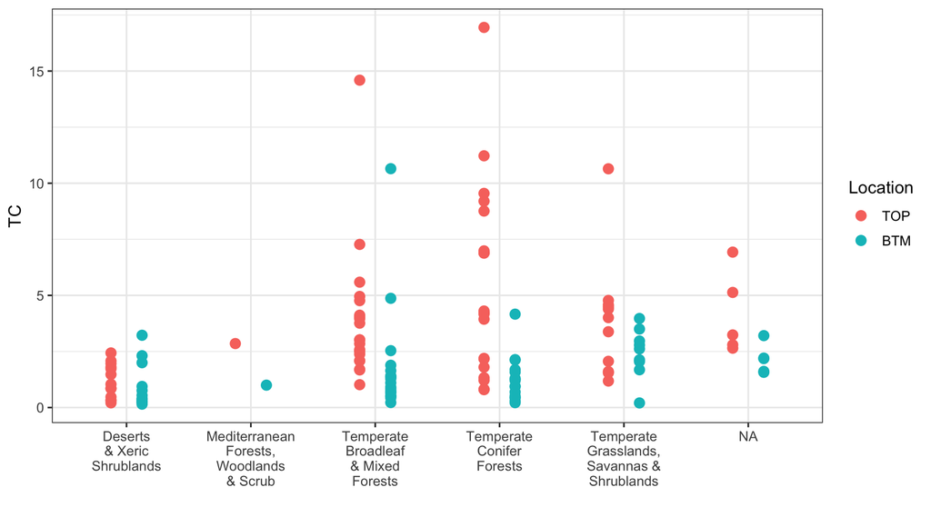

```r
bgc_data %>%
  ggplot(aes(x = biome_name, y = TC, color = Location))+
  geom_point(size = 3,
             position = position_dodge(width = 0.5)) +
  scale_x_discrete(labels = function(x) str_wrap(x, width = 10))+
  labs(x = "")
```

## CORRELATION PLOTS

Here is simple code to visualize correlations among variables. You can also do this in the [Shiny App](https://shinyproxy.emsl.pnnl.gov/app/1000soils).

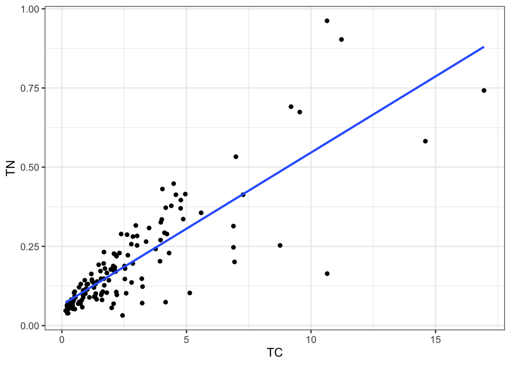

```r
bgc_data %>%
  ggplot(aes(x = TC, y = TN))+
  geom_point()+
  geom_smooth(method = "lm", se = F)
```

## MAPS

The `{ggplot2}` package has functionality to easily plot maps (without downloading any other files or packages!).

We will plot our data over a map of the USA.  
To do so, first load the `states_map` file, which contains the data for the state outlines.  
Then, plot the state boundaries using the `geom_polygon` function.

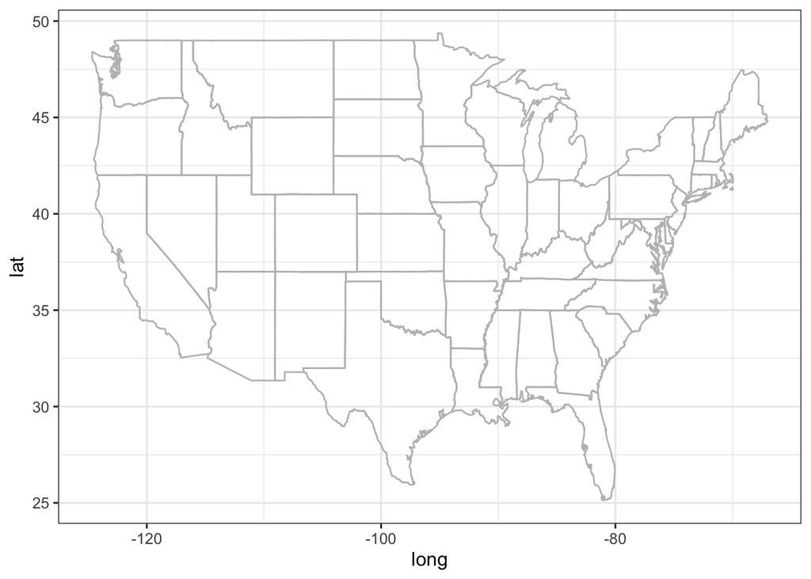

```r
states_map <- ggplot2::map_data("state")

ggplot(states_map, aes(long, lat, group = group))+
  geom_polygon(color = "grey", fill = NA)
```

Now, to plot our data over this map.  
We add the `geom_point` layer over the base polygon layer of the states.

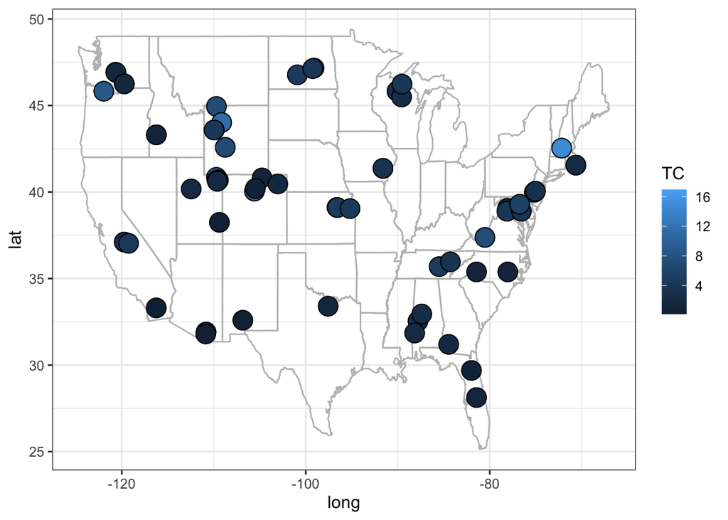

```r
ggplot(states_map, aes(long, lat, group = group))+
  geom_polygon(color = "grey", fill = NA)+
  geom_point(data = bgc_data,
             aes(x = Long, y = Lat,
                 fill = TC, group = 1),
             size = 6, shape = 21, color = "black")
```

The default `{ggplot2}` color palette may be difficult to interpret.  
As an alternative, we use the `{soilpalettes}` package.

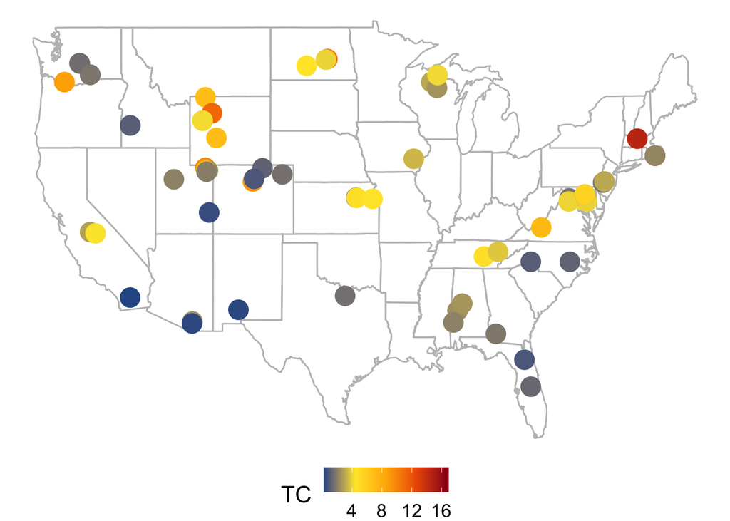

```r
ggplot(states_map, aes(long, lat, group = group))+
  geom_polygon(color = "grey", fill = NA)+
  geom_point(data = bgc_data %>% filter(Location == "TOP"),
             aes(x = Long, y = Lat, color = TC, group = 1),
             size = 6)+
  scale_color_gradientn(colors = soil_palette("redox2", 5))+
  theme_void(base_size = 16)+
  theme(legend.position = "bottom")
```

Another map example, showing the different biomes

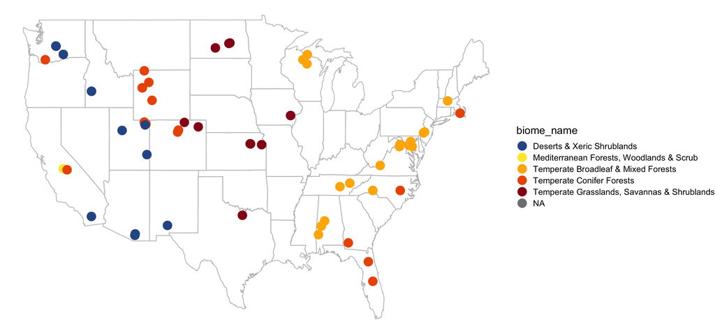

```r
ggplot(states_map, aes(long, lat, group = group))+
  geom_polygon(color = "grey", fill = NA)+
  geom_point(data = bgc_data,
             aes(x = Long, y = Lat,
                 color = biome_name, group = 1),
             size = 6)+
  scale_color_manual(values = soil_palette("redox2", 5))+
  theme_void(base_size = 16)+
  labs(fill = "")
```

## ANOVA

We can use analysis of variance (ANOVA) to determine the drivers of variation in our dataset.  
In our current dataset, we have two categorical variables (Location and biome_name), which we will use as the explanatory variables.

To generate the ANOVA table, we first run a linear model (`lm` function) and then the anova (`Anova` function). You will need the `{car}` package for this.

```r
l = lm(TC ~ Location * biome_name, data = bgc_data)
car::Anova(l)
```

```
## Anova Table (Type II tests)
##
## Response: TC
##                     Sum Sq  Df F value   Pr(>F)
## Location            151.92   1 24.2377  2.9e-06 ***
## biome_name           92.18   4  3.6768 0.007448 **
## Location:biome_name  61.48   4  2.4521 0.049940 *
## Residuals           714.55 114
## ---
## Signif. codes:  0 '***' 0.001 '**' 0.01 '*' 0.05 '.' 0.1 ' ' 1
```

We encourage you to use the framework above to perform additional analyses on the dataset provided. What trends do you see in the data?

Some prompts:

- what is the spatial distribution of [x]?
- how does analyte [x] differ by depth or among biomes?
- how well does analyte [x] correlate with analyte [y]?
- choose a site; how do the data for that site compare to the others in that region/biome?